# Lab 4 - Shawn Cicoria

# 2. The data set rivers contains the lengths (in miles) of 141 major rivers in North America

> 1. What proportion are less than 500 miles long?

```r
data("rivers")
#str(rivers)

#nrow(rivers[rivers < 500])/nrow(rivers)
length(rivers[rivers < 500]) / length(rivers)
```

```
[1] 0.5815603
```

```r
cat(sprintf("proportion rivers < 500 miles: %f", sum(rivers < 500)/ length(rivers)))
```

```
proportion rivers < 500 miles: 0.581560
```

> 2. What proportion are less than the mean length?

```r
cat(sprintf("proportion rivers < mean of all rivers: %f",sum(rivers < mean(rivers)) / length(rivers)))
```

```
proportion rivers < mean of all rivers: 0.666667
```

> 3. What is the 0.75 quantile?

```r
summary(rivers)
```

```
   Min. 1st Qu.  Median    Mean 3rd Qu.    Max.
  135.0   310.0   425.0   591.2   680.0  3710.0
```

```r
summary(rivers)[[5]]
```

```
[1] 680
```

```r
cat(sprintf("\n0.75 quantile: %d ", summary(rivers)[["3rd Qu."]]))
```

```
0.75 quantile: 680
```

## 3. Fit a density estimate to the data set pi2000 (UsingR). Compare with the appropriate histogram. Why might you want to add an argument like breaks =0:10-0.5 to hist()?

Using the `break` of `0:10-.5` shifts the x-axis so the bar is centered over `0` in addition to creating 10 bins – offset by `-0.5`

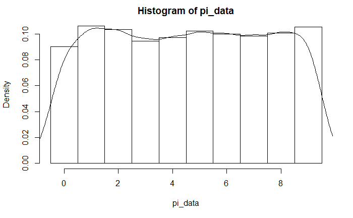

```r
#data("UsingR::pi2000")

pi_data <- UsingR::pi2000

#par(mfrow=c(1,2))

# freq = FALSE is opposite of probability = TRUE
hist(pi_data, freq = FALSE, breaks = 0:10-.5)
lines(density(pi_data))
```

```r
NA
NA
```

## 4. The data set DDT (MASS) contains independent measurements of the pesticide

DDT on kale. Make a histogram and a boxplot of the data. From these, estimate the mean and standard deviation. Check your answers with the appropriate functions.

```r
par(mfrow=c(1,2))
ddt <- MASS::DDT

hist(ddt, main="DDT in Kale")
boxplot(ddt, main="DDT in Kale boxplot", ylim = c(2.5,4.8))
```

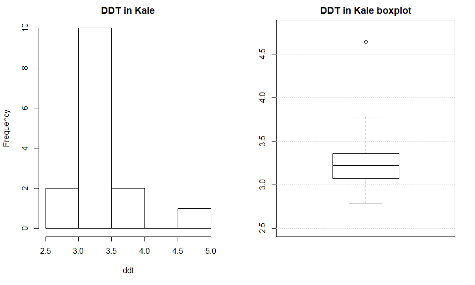

```r
grid(nx=NA, ny=NULL)
```

#### Mean and SD guess

The mean from the boxplot is somewhere just north of `3.25` as the middle of the boxplot is the `50%` (median) and there are outliers.

For the SD guess, we have an IQR of `3.3 - 3.1 = 0.2`. Normally we can guess that the `75%` of that IQR is the SD. So, the guess is `SD = 0.15`

> From https://handbook-5-1.cochrane.org/chapter_7/7_7_3_5_mediansand_interquartile_ranges.htm – where they use `1/1.35` which is approx `75%`

Clearly, this guess didn’t work.

```r
ddt_mean=mean(ddt)
ddt_sd=sd(ddt)
cat(sprintf("mean: %f   and standard deviation %f\n\n", ddt_mean, ddt_sd))
```

```
mean: 3.328000   and standard deviation 0.437153
```

```r
summary(ddt)
```

```
   Min. 1st Qu.  Median    Mean 3rd Qu.    Max.
  2.790   3.075   3.220   3.328   3.360   4.640
```

```r
IQR(ddt)
```

```
[1] 0.285
```

## 5. It can be illuminating to view two different graphics of the same data set at once.

A simple way to stack graphics is to specify that a figure will contain two graphics by using the command

```
> par(mfrow=c(2,1) # 2 rows, 1 column for graphic figures
```

Then, if x is the data set, the commands

```
> hist(x)
> boxplot(x, horizontal=TRUE)
```

### will produce stacked graphics. (The graphics device will remain divided until you change it back with a command such as par (mfrow=c(1, 1)) or close the device.)

### For the data set lawsuits (UsingR), make stacked graphics of lawsuits and log (lawsuits). Could you have guessed where the middle 50% of the data would have been without the help of the boxplot?

In general, it would be impossible without using a logarithmec transformation of the data in order to bring it to a normal distribution

```r
law_suites <- UsingR::lawsuits

par(mfrow=c(2,2))

hist(law_suites, main="Histogram Lawsuits")
boxplot(law_suites, main="boxplot Lawsuites")
```

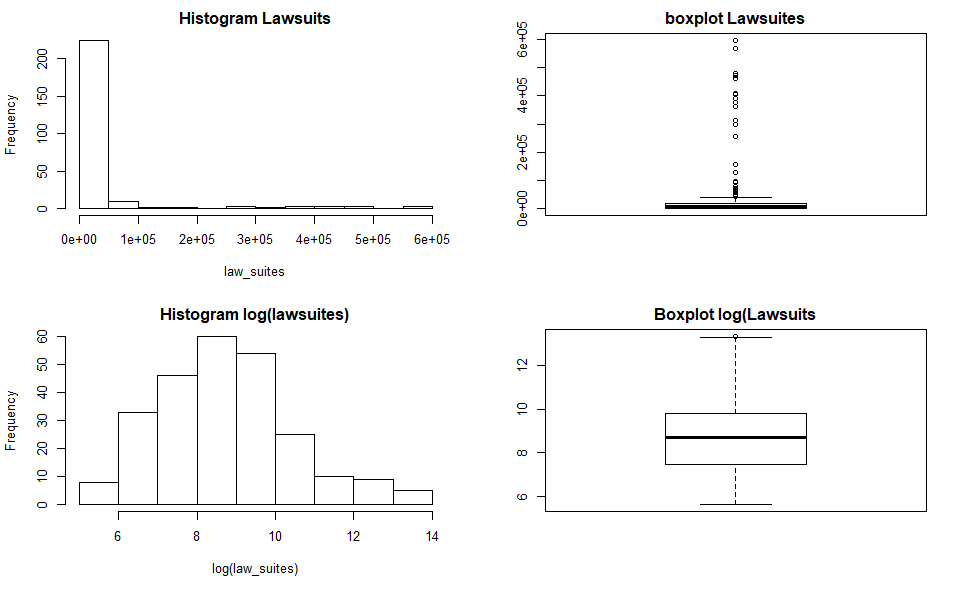

```r
hist(log(law_suites), main="Histogram log(lawsuites)")
boxplot(log(law_suites), main="Boxplot log(Lawsuits")
```

## 6. Let sex = c(1,1,1,1,2,2,2,2,2,2); smoking = c(1,0,1,0,1,0,0,0,1,1); age=c(31:40) in R. A data frame is constructed as zz = data.frame(sex, smoking, age). Give the results of following R commands:

> 1. apply(zz[-1,], 2, min)

for all but first row (subset), find the minimum of each column

> 2. zz[zz[,3]>35,]

where the third column is greater than 35, print subset that item, and return all columns.

> 3. zz[order(zz[“smoking”], zz[“age”]), ]

sort zz by smoking, then age, then return all rows, columns

> 4. subset(zz, zz[“sex”]==1)

slice out (subset) only rows where sex == 1, return all columns

> 5. tapply(zz$age, zz$smoking, max)

> 6. apply(zz[,-3], 1, function(x){ sum(x) })

dropping the `age` column (index 3), then on each row (MARGIN=1), sum each column left - so sum sex and smoking

**i got this wrong, as MARGIN=2 would’ve done what I expressed. Instead this sums each row across for just sex and smoking – so a way to aggregate rows cross columns**